# Distance Weighting Functions for Spatial Covariance Models

Guillaume Guénard

31/10/2019

# Distance weighting functions

The the present study is concerned with the development of a spatial modelling framework. In a nutshell, its consists in:

1. finding a function of the distance that is suitable to represent the spatial covariance,
2. decompose these spatial covariance patterns as a set of eigenfunctions, and
3. use these eigenfunctions with ancillary representation methods (e.g., linear models, generalized linear models, discriminant functions, articifical neural networks).

Its purpose is to incorporate the information about where observations were taken from (i.e., the spatial information) into analytical and predictive models.

Distance weighting functions (DWF) describe relationships between the distances, which are represented as matrix $\mathbf{D} = [d_{i,j}]$ of pairwise geographic distance between the sites (or between the obserations and a set of representative kernels), and their corresponding degree of association, which is represented as matrix $\mathbf{W}=[w_{i,j}]$. Finding a suitable DWF is at the basis of representing spatial patterns. The DWF is used to estimate the spatial covariance (matrix $\mathbf{\Sigma}$, step #1 in the list above). In the framework developed here, $\mathbf{W}$, obtained by applying the a DWF on $\mathbf{D}$ in an element-wise manner. The complete process is described in-length in the main text and involves centering $\mathbf{W}$ on its columns (i.e., the resulting transformed columns have means of $0$) and multiplying it by its own transpose. That last step garranties that the spatial covariance matrix remains positive semi-definite, which is expected by the maximum likelihood estimator (MLE). That estimator is, in turn, necessary to determine which DWF to choose from and the most adequate values for its parameters. In in developing the DWF, we have followed a few guidelines to help in obtaining well-behaved MLE. A DWF:

1. has unit range on its entire domain, with the maximum weight being $1$ and occurring when the distance is $0$, since $w(d=0)=1$, and the minimum weight being $0$ and occurring when $d\geq \beta$ (i.e., $w(d\geq\beta)=0)$, where $\beta$ is the parameter describing the maximum influence distance;
2. is continuous between $d=0$ and $d=\beta$;
3. is monotonically decreasing between $d=0$ and $d=\beta$;
4. converges into the same linear function $w=1-d/\beta$ when its shape parameter $\alpha=1$ and into a Kronecker’s $\delta$ (i.e., a function giving the value $1$ for $d=0$ and $0$ everywhere else) when $\alpha=0$;
5. is initially steep, with its first derivatives with respect to $d$ having values $\leq-1/\beta$ at $d=0$, which are then increasing to values $\leq 0$ at $d=\beta$;
6. has a first derivatives with respect to $d$ that always increasing, i.e., its second derivative with respect to $d$ has a value $\geq 0$ between $d=0$ and $d=\beta$; and
7. has a parameter $\alpha$, driving its shape in the $0<\alpha<1$ interval.

Below, we describe five DWF. Some of them where loosely inspired by variogram models used in kriging, whereas others are from standard analytic geometry, with all the them complying with the properties enumerated above.

## Spherical function

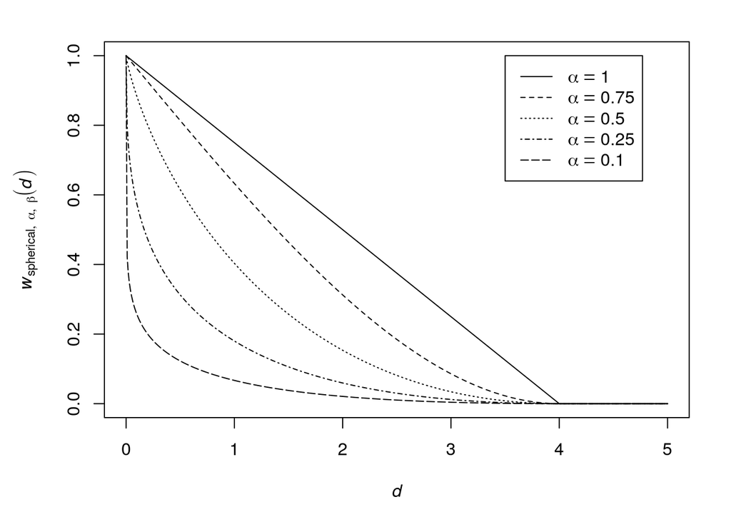

Example of the spherical DWF for different values of $\alpha$ and $\beta=4$.

## Exponential function

The second function we considered was the exponential variogram function, which we adapted to the framework described previously as follows:
$$w_{\beta}(d) = \dfrac{\mathrm{e}^{\frac{-3d}{\beta}}-\mathrm{e}^{-3}}{1-\mathrm{e}^{-3}}.$$
To enable one to modulate its shape, we began by replacing the value $-3$ by a parameter $a$ as follows:
$$w_{a,\beta}(d) = \dfrac{\mathrm{e}^{\frac{ad}{\beta}}-\mathrm{e}^a}{1-\mathrm{e}^a},$$
with values of $a\in[-\infty,0]$ giving curves complying with above properties 1-3. By posing $a=(\alpha-1)/\alpha$, we obtained the following:
$$w_{\alpha,\beta}(d) = \dfrac{\mathrm{e}^{\frac{(\alpha-1)d}{\alpha\beta}}-\mathrm{e}^\frac{\alpha-1}{\alpha}}{1-\mathrm{e}^\frac{\alpha-1}{\alpha}},$$
which comply with properties 5-6. The first derivative of that function with respect to $d$ is:
$$w'_{\alpha,\beta}(d) = \dfrac{\left(\alpha-1\right)\mathrm{e}^\frac{\left(\alpha-1\right)d}{\alpha \beta}}{\alpha\beta\left(1-\mathrm{e}^\frac{\alpha-1}{\alpha}\right)}.$$
That function can be used to help in interpreting DWF parameters fit to empirical data.

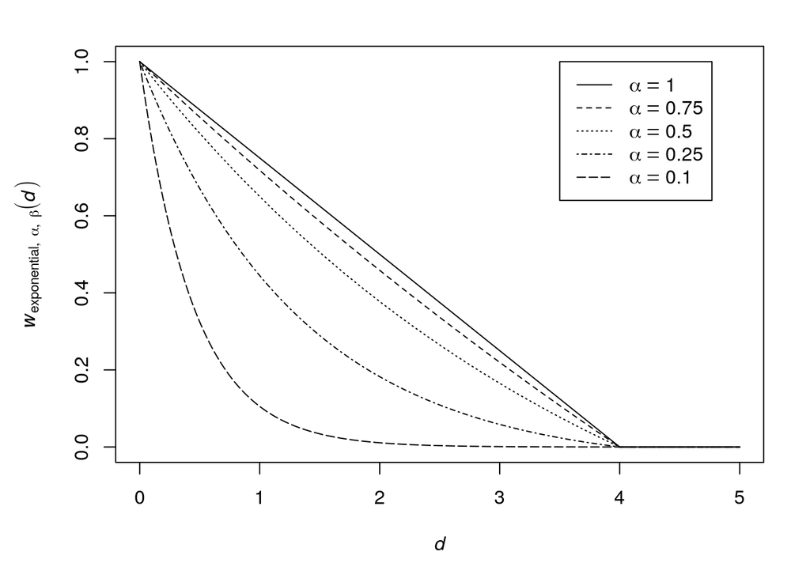

Example of the exponential power weighting for different values of $\alpha$ and $\beta=4$.

We did not seek to develop DWF on the basis of the Gaussian and hole effect variograms models. The Gaussian variogram model has a slope that is consistently above $-1/\beta$ and is not adaptable to the present framework. The hole effect variogram model, which is based on the canonical sine function, is not consistently decreasing. The next weighting function were developed from general analytic geometric functions that are not commonly used as variogram models.

## Power function

We began the definitions of the third weighting function, which we called the «power» weighting function, by considering a simple linear function of the form $y = ax+b$, with $a = -\frac{1}{d_{max}}$ and $b = 1$ to comply with the properties mentioned previously, and raised it to the inverse of $\alpha$ as follows:

$$w_{\alpha,\beta}(d) = \left(1-\dfrac{d}{\beta}\right)^\frac{1}{\alpha},$$

with its first derivative with respect to $d$ being:

$$w'_{\alpha,\beta}(d) = -\dfrac{\left(1-\frac{d}{\beta}\right)^{\frac{1}{\alpha}-1}}{\beta\alpha}.$$

Value of the derivative at limit $d=0$ is thus $-\frac{1}{\beta\alpha}$ for all $\alpha \in ]0,1]$ whereas at limit $d=\beta$ it is $-\frac{1}{\beta}$ whenever $\alpha=1$ and $0$ for all $\alpha \in ]0,1[$.

As for all above-defined DWF, the power weighting function takes the shape of a straight line when $\alpha = 1$ whereas for other non-zero $a<1$ it takes the shape of curves starting steeply (the smaller the $\alpha$, the steeper the curve starts) and ending gently (the smaller the $\alpha$ the gentler the curve ends).

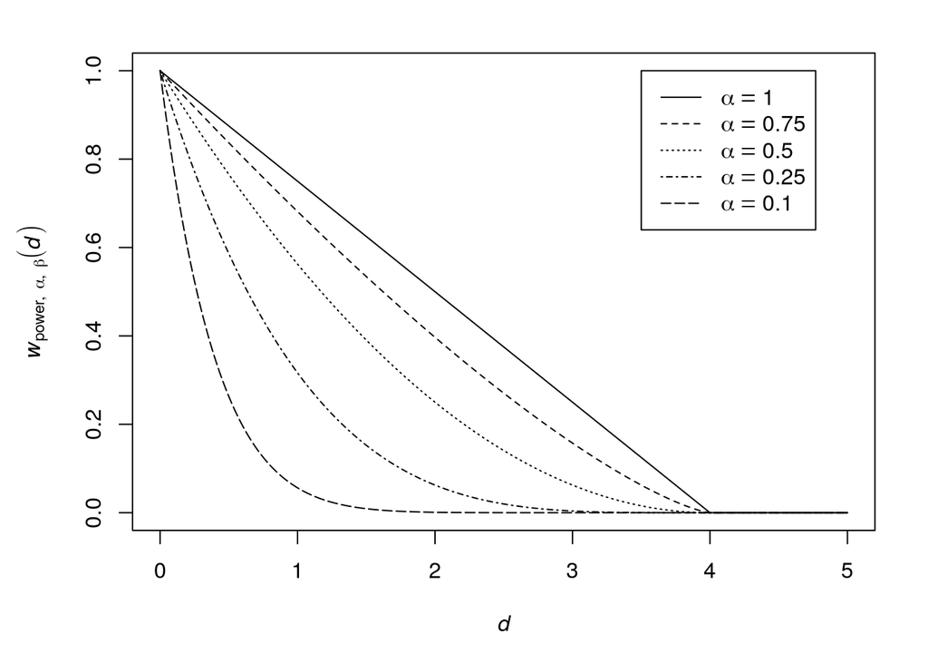

Example of the power weighting for different values of $\alpha$ and $\beta=4$.

## Hyperbolic weighting function

and with its first derivative with respect to $d$ being:

$$w'_{d_\alpha,\beta}(d)=\dfrac{\left(2-\frac{1}{\alpha}\right)\left(d+1\right)^{1-\frac{1}{\alpha}}}{1-\left(\beta+1\right)^{2-\frac{1}{\alpha}}}$$
for $\alpha\in [0,1]\not\,\,\lbrace 0.5 \rbrace$ and:
$$w'_{d_\alpha,\beta}(d)=-\dfrac{1}{\log(\beta+1)(d+1)}$$
for $\alpha=0.5$. The function features a steep initial slope and a gentle final slope, with initial steepness (and final gentleness) being more pronounced for small values of $\alpha$. As for the spherical and power weighting functions, it amounts to the linear function $w=1-d/\beta$ when $\alpha=1$.

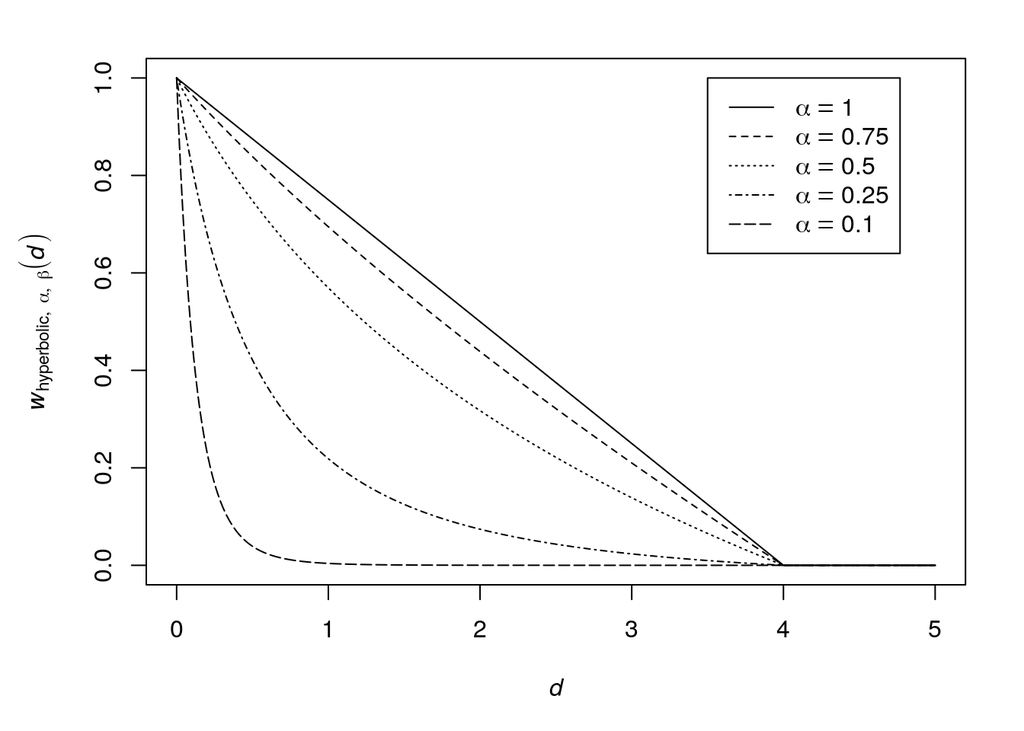

Example of the hyperbolic weighting for different values of $\alpha$ and $\beta=4$.

## Superelliptical weighting function

Finally, we called the fifth and last weighting function «superelliptical» weighting function as it is based on superelliptical (also known as the Lamé) curves, a generalization the equation of an ellipse. As such, its first derivative with respect to $d$ has the value $-\infty$ at $d=0$ and $0$ at $d=\beta$. It is defined as follows:
$$w_{\alpha,\beta}(d) = 1-\dfrac{\left(\beta^\frac{1}{\alpha}-\left(\beta-d\right)^\frac{1}{\alpha}\right)^\alpha}{\beta}$$

and corresponds exactly to the lower-left portion of a vertically-compressed ellipse going through point $(d=0,w=1)$ and $(d=\beta,w=0)$ when $\alpha=0.5$. Its first derivative with respect to $d$ is:

$$w'_{\alpha,\beta}(d) = -\dfrac{\left(\beta^\frac{1}{\alpha}-\left(\beta-d\right)^\frac{1}{\alpha}\right)^{\alpha-1}\left(\beta-d\right)^{\frac{1}{\alpha}-1}}{\beta}.$$

The shape of the function becomes increasingly rectangular as one decreases $\alpha$ from $0.5$ toward $0$ and increasingly linear as one increases $\alpha$ from $0.5$ toward $1$. As for the spherical, hyperbolic, and power weighting function, the superelliptical weighting function becomes a straight line when $\alpha=1$.

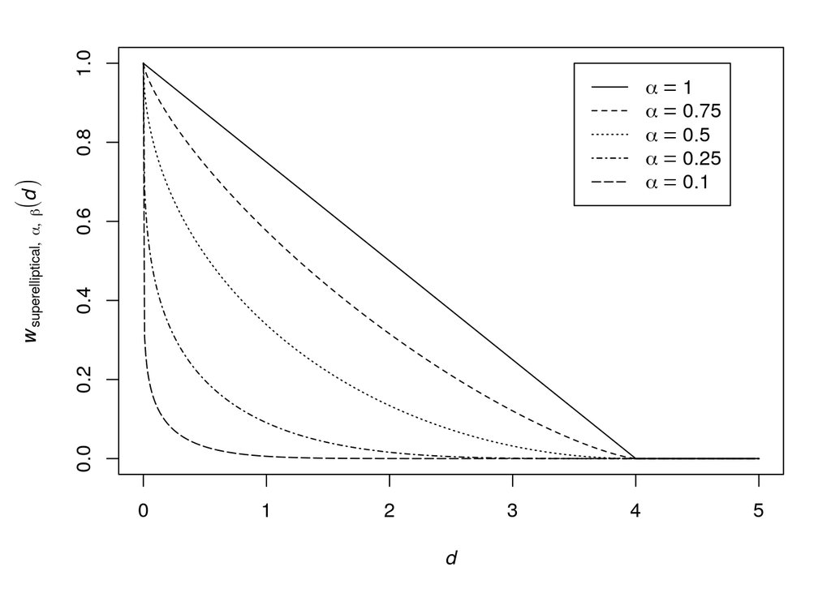

Example of the superelliptical weighting for different values of $\alpha$ and $\beta=4$.

Although it is our hope that the five DWF presented here cover a broad array of possible distance-weights relationships, it is by no mean an exhaustive listing of all the possible relationships that can be used for modelling spatial covariance from among-site distances. It is also our hope that scientists supply any lack of a relevant function that may arise in the future.